# Active modification of cavity nest‐entrances is a common strategy in arboreal ants - Priest - - Biotropica - Wiley Online Library

[Biotropica](https://onlinelibrary.wiley.com/journal/17447429)

[Early View](https://onlinelibrary.wiley.com/toc/17447429/0/0)

ORIGINAL ARTICLE

Full Access

# Active modification of cavity nest‐entrances is a common strategy in arboreal ants

[Galen V. Priest](https://onlinelibrary.wiley.com/action/doSearch?ContribAuthorStored=Priest%2C+Galen+V)

[Flávio Camarota](https://onlinelibrary.wiley.com/action/doSearch?ContribAuthorStored=Camarota%2C+Fl%C3%A1vio)

[Heraldo L. Vasconcelos](https://onlinelibrary.wiley.com/action/doSearch?ContribAuthorStored=Vasconcelos%2C+Heraldo+L)

[Scott Powell](https://onlinelibrary.wiley.com/action/doSearch?ContribAuthorStored=Powell%2C+Scott)

[Robert J. Marquis](https://onlinelibrary.wiley.com/action/doSearch?ContribAuthorStored=Marquis%2C+Robert+J)

First published: 02 March 2021

https://doi.org/10.1111/btp.12922

**Associate Editor::** Eleanor Slade

**Handling Editor::** Xavier Arnan

Galen V. Priest and Flávio Camarota are contributed equally to this manuscript.

## Abstract

The majority of tropical arboreal ant species nest in tree cavities. These cavities, often produced initially by wood‐boring beetles, can be in live or dead wood and represent long‐lasting and highly defensible nesting resources. Yet the size of cavity entrances can constrain their use. Active entrance modification may be an effective way to overcome this constraint. Here, we conduct the first systematic study of nest‐entrance modification in an arboreal ant community. Using field experiments deployed across a number of tree species, we show that 14% of 2631 experimental cavities were modified by either enlargement, or reducing entrance size by construction. Entrance modifications, which were made by a majority (18/29 species) of the species that occupied experimental nests, used a variety of construction techniques and materials. Combined, these modifications were context‐dependent with respect to available entrance sizes: Enlargement was more common when the diversity of available entrance sizes was limited, whereas reduction was more prevalent when the diversity of entrance sizes was higher. Nevertheless, the context of tree species identity did not significantly influence the number of modified cavities or the construction materials. Overall, we show that nest‐entrance modification is a widespread, active, and context‐dependent strategy in the nesting ecology of arboreal ants.

## 1 INTRODUCTION

The remarkable diversity and ecological dominance of arboreal ants in tropical systems (Davidson, 1997; Davidson et al., 2003; Davidson & Patrell‐Kim, 1996; Floren et al., 2002; Tobin, 1995) is largely underpinned by an underappreciated dependency on pre‐existing shelter resources. More specifically, the majority of tropical arboreal ant species nest in cavities in dead or living wood (e.g., Carroll, 1979; Klimes et al., 2012; Klimes & McArthur, 2014; Philpott & Foster, 2005; Powell et al., 2011; Tanaka et al., 2009), which are often the direct or indirect product of wood‐boring beetle damage (e.g., Blüthgen & Feldhaar, 2010; Creighton, 1963; Novais et al., 2017; Powell, 2008). Arboreal cavities provide durable, long‐lasting nests that are defensible against competitors and predators, while ameliorating abiotic conditions. Beyond the initial colony founding stage, many arboreal ant species also grow their colony by expanding into more than one cavity on their home tree (i.e., polydomy; Debout et al., 2007), such that they are continually hunting for additional suitable cavities, including those already occupied by other co‐occurring species (Powell, 2009; Powell et al., 2017; Powell & Dornhaus, 2013). Cavity usurpation can therefore be a constant threat to arboreal cavity‐dwelling ant species (Powell, 2009; Powell et al., 2017). Moreover, this intense competition documented for individual species also scales to a signature of cavity limitation at the community level, with detectable influences on assembly (Jiménez‐Soto & Philpott, 2015; Philpott & Foster, 2005; Powell et al., 2011). Yet despite the critical nature of the cavity resource‐base for arboreal ants, our understanding of how different ant species select and use shelter resources remains relatively limited.

Given intense competition over cavity resources, selection for strategies to effectively acquire and defend nests is likely to be strong. Selection of a specialized range of entrances sizes that closely match ant head size appears to be a common strategy among arboreal ants (Camarota et al., 2020; Powell et al., 2020) resulting in potential benefits for maximizing entrance defensibility. Indeed, some arboreal ant lineages have evolved soldiers with specialized head morphology for defensive blocking of their nest cavities (Dornhaus & Powell, 2010; Powell et al., 2020; Wills et al., 2018) and selection of entrances that precisely fit the head of their defensive soldier caste (Powell, 2009, 2016; Powell et al., 2020). However, this general strategy is dependent on the availability of cavity entrances that appropriately match ant size, as dictated by the diversity and abundance of pre‐existing cavity entrances. Moreover, cavity availability has cascading implications for the growth and persistence of the colony, and ant‐community structure. For instance, greater availability of a variety of entrance sizes increases the diversity of colonizing species (Jiménez‐Soto & Philpott, 2015; Powell et al., 2011). Moreover, expansion into new cavities is both critical for colony growth and can be constrained when available entrance sizes do not match the preferred size of a species (Powell, 2009).

One way that arboreal ant species might deal with natural constraints on the abundance and properties of available cavities is by modifying unsuitable entrances to better fit their head or body size. Two options seem reasonable: they can excavate the wood to enlarge existing entrances, or reduce the entrance size via construction inside the original entrance hole. Some taxa are especially well known for their capacity to excavate in wood (Sanders, 1964), and the strategies of enlarging or reducing cavity entrances have been reported for some taxa (e.g., Lanan et al., 2011; Pratt & Pierce, 2001). Nevertheless, because neither strategy has been studied systematically, we currently have no understanding of the prevalence of entrance modification within diverse arboreal ant assemblages. A better understanding of these strategies would give important new insights into the level of ecological plasticity in the nesting niche among species, and into how such plasticity may facilitate coexistence.

Here, we conduct the first detailed examination of nest‐entrance modification in a diverse arboreal ant community. We used field experiments to examine the overarching hypothesis that entrance modifications are widespread among arboreal ants and influenced by the available nest‐entrance diversity and the tree species upon which the cavities are found. There are marked differences in the beetle damage among different individual trees and tree species (G. V. Priest, F. Camarota, S. Powell, H. L. Vasconcelos, & R. J. Marquis, unpublished data), so the structure of available beetle damage on a tree may change the modification activities of the resident ants. Similarly, different tree species may provide different raw materials for entrance modifications. Our first experiment focused on the combined role of tree‐level differences in the number and range of different entrance sizes available to the ants, defined here as entrance diversity, on the frequency of entrance enlargement and reduction (“entrance‐diversity experiment” hereafter). In this experiment, our two entrance diversity treatments differed in both the number of different entrance sizes provided and the total range they spanned. This was done to mimic the extremes of available beetle damage previously quantified in the focal system (G. V. Priest, F. Camarota, S. Powell, H. L Vasconcelos, & R. J. Marquis, unpublished data). Our second experiment then detailed the role of tree species on how entrance reductions are achieved (“tree‐diversity experiment” hereafter) and did not consider enlargement behavior as it does not require tree‐derived materials. In testing our hypothesis with these two experiments, we addressed the following key questions: (1) How frequently are cavity entrances modified within the focal arboreal ant assemblage? (2) What kinds of construction methods and materials are used to reduce entrance size across ant species? (3) Which ant species engage in entrance modification and what kinds of modification do they make? (4) How do the contexts of available entrance diversity and tree species alter the frequency and type of entrance modifications made by arboreal ants?

## 2 METHODS

### 2.1 Study area

Fieldwork was conducted at the Reserva Ecológica do Panga (19°10′S, 48°23′W), a 409 ha reserve located 35 km south of Uberlândia, Minas Gerais, Brazil. The region is characterized by a tropical climate, with a dry winter from May to September, and a rainy summer from October to April. The temperature and mean annual precipitation are 22°C and 1650 mm, respectively. The reserve consists of mixed Cerrado vegetation (Cardoso et al., 2010), though the two experiments were conducted in the typical intermediate physiognomy of the biome (‘*cerrado sensu stricto’*), with approximately 30% crown cover and therefore an intermediate level of canopy connectivity for the system (Oliveira‐Filho & Ratter, 2002). Although both experiments were conducted in the same physiognomy, there were some marked differences in tree density, mostly due to a fire that occurred less than one year before the tree‐diversity experiment. Therefore, in the tree‐diversity experiment, the vegetation complexity was reduced compared to the entrance‐diversity experiment.

### 2.2 Cavity experiments

#### 2.2.1 Entrance‐diversity experiment

We placed 27 experimental cavities in each of eighty *Caryocar brasiliense* Camb. (Caryocaraceae) trees (13.9 to 27.1 cm diameter at the base of the tree (DAB); 2160 cavities in total), with the properties of the cavities varying by treatment. Two entrance‐diversity treatments were used in the study and they combined different numbers of discrete entrances sizes and spanned different ranges, as follows: (1) Low entrance diversity (LED) treatment, consisting of nine cavities of each of three entrance diameters (1.5, 2.0, 2.5 mm) that span a narrow range; (2) High entrance diversity (HED) treatment, consisting of three cavities of each of nine entrance diameters (1.5, 2.0, 2.5, 3.0, 3.5, 4.0, 4.5, 5.0, 5.5 mm) that span a broader range. These entrance‐diversity treatments were chosen to mirror the extremes of the natural entrance diversity within the focal habitat, based on previous cavity surveys across six tree species that included *Caryocar brasiliense* (G. V. Priest, F. Camarota, S. Powell, H. L. Vasconcelos, & R. J. Marquis, unpublished data). The goal of this design was then to provide treatments that matched a natural resource‐base that covaried in entrance size number and range, not to assess the contribution of entrance size number and range separately. The full experimental design of the study that these data come from consisted of a factorial design, with entrance size diversity and cavity volume as main factors. However, cavity volume was not considered here as it had no influence on the cavity modifications that are the focus of the present analysis. Aside from the controlled differences in entrance size and cavity volume, all experimental cavities shared the same design. The cavities were constructed from locally obtained wooden poles 3 cm in diameter, and were of a variety of hardwood tree species. The poles were cut into 10 cm lengths and drilled lengthwise from one end to a depth of 9 cm. A single entrance hole was drilled perpendicular to the cavity bore approximately one‐third the distance from the closed end. The main cavity was blocked by a latex stopper. The experiment was setup in the field in July of 2011 and ran for 18 months.

#### 2.2.2 Tree‐diversity experiment

Six experimental cavities were placed on each of 30 individual trees from each of four tree species, for a total of 120 experimental trees and 720 experimental nests. The four tree species were *Caryocar brasiliense* Camb. (Caryocaraceae), *Machaerium opacum* Vogel (Fabaceae), *Qualea grandiflora* Mart. (Vochysiaceae), and *Tachigali aurea* (Tul.) Baill (Fabaceae). All trees were between 4.8–14.4 cm DAB. Experimental cavities were constructed as in the entrance‐diversity experiment (above). Each tree received the same treatment of six experimental cavities, consisting of four entrance areas (4.4, 6.6, 12.4, 31.7 mm<sup>2</sup>) in a ratio of 1:2:2:1, respectively. These areas have an approximate diameter of 2.4, 2.9, 4.0, and 6.4 mm, respectively. Previous work has shown that the intermediate entrance sizes are used more frequently within the focal system (Powell et al., 2011), so this ratio provided greater availability for the more extensively used sizes. Entrances were measured as entrance areas in the tree‐diversity experiment, instead of being simplified to diameters, because many of the reduced entrances were not circular and so area was a more accurate representation of size and size change over the original entrance (below). Cavities were placed on trees in July–August 2015, and collected 12 months later.

### 2.3 Nest collection and processing

Upon collection of the nests, entrance holes were sealed with tape to avoid losing any inhabitants and frozen for at least 24 h to ensure easy collection of entrance data and removal of inhabitants. For the tree‐diversity experiment, with its focus on the construction methods used by the ants in entrance reduction, a metal ring made from bailing wire was placed around the entrance hole prior to taping, to prevent damage to constructed modifications. The intact, reduced entrance holes were then photographed to quantify both the reduced entrance size and the original entrance size in the cavity wood. Photos were taken looking directly down into the entrance while ensuring sharp focus on the edge of the opening (using an Olympus e‐M5 camera with an Olympus M. Zuiko 12–50 mm F/3.5–6.3 lens in macro mode). A set of digital calipers was used as an in‐shot scale, placing the jaws on the same focal plane as the entrance to minimize distortion and scaling inaccuracy. If necessary, a second photo was taken with cavity modifications removed to measure area of the unmodified entrance. All entrance areas were measured using Fiji (Rueden et al., 2017; Schindelin et al., 2012), with the brightness threshold tool used to delineate entrance area. In some cases, photos were adjusted using PhotoScape photo editing software to facilitate calculation of entrance area.

After processing the entrance data, all occupants, including adult ants and other arthropods, were counted and stored in 92.4% ethanol. The presence of any queens, alates, or brood was noted. At least one ant specimen from each nest was mounted for subsequent identification to the level of species or morphospecies. Non‐ants were usually identified to the level of order, less frequently to family. Ants were identified using the voucher collection at the Universidade Federal de Uberlândia (UFU), Laboratório de Ecologia de Insetos Sociais. Ant voucher specimens are held in the Zoological Collection of UFU.

### 2.4 Statistical analyses

For the entrance‐diversity experiment, the influence of entrance size diversity on entrance enlargement and reduction was assessed via one‐way ANOVAs. One test was used to assess the number of enlarged entrances, with the entrance‐diversity treatments as factors (LED and HED), while the second was used to assess the number of reduced nests in relation to the entrance‐diversity treatments.

For the tree‐diversity experiment, Fisher exact tests were used to assess differences in the materials that ant species used to modify the entrances, and the influence of tree species on the amount of modifications performed by the ants. A paired *t*‐test was conducted to compare cavity entrance sizes before and after modifications by the ants. A Welch's two‐sample *t*‐test was performed to assess whether the modified cavities of the most common ant species reducing cavities on the tree‐diversity experiment had significantly smaller entrance areas than the unmodified cavities used by those species. Finally, to test whether original entrance size predicts the presence/absence of modification, logistic regression was used to model the relationship of the probability that a cavity entrance was modified or not using the original area of the cavity entrance as the independent variable. All tests were performed in R Software, version 3.5.1 (R Core Team, 2018).

## 3 RESULTS

### 3.1 Overall nest retrieval, ant diversity, and prevalence of cavity modifications

Across the two experiments, more than 90% of the nests deployed at the start of the experiments were retrieved at the end (entrance‐diversity experiment: 1978 of 2160 nests, 92%; tree‐diversity experiment: 653 of 720, 91%). For these retrieved experimental nests, 51% and 38% were occupied by ants, respectively, by a total of 29 ant species (Table S1). This total ant diversity included nine *Cephalotes* species, seven *Camponotus* species, and six *Pseudomyrmex* species, indicating strong occupation rates by members of the three particularly diverse arboreal ant genera in Neotropical systems. In contrast to the ant diversity, only 3.3% and 1.3% of cavities were occupied by other arthropods, respectively.

In the entrance‐diversity experiment, in which we recorded both enlarged and reduced entrances, a total of 237 cavities had modified entrances, and 169 of these were also occupied by ants at the time of collection. In the tree‐diversity experiment, in which we recorded only constructed entrance reductions, a total of 117 cavities had reduced entrance holes, and 71 of these were also occupied by ants at the time of collection (Table 1). The high level of ant occupation versus low occupation by all other arthropods (above), combined with the consistent types of entrance modifications (below) across cavities that were ant‐occupied and unoccupied at the time of collection, suggests that the majority of modifications were made by ants. For completeness, subsequent analyses therefore considered all cavities with entrance modifications, while also focusing on the majority of cavities with modified entrances that were also occupied by ants at the time of collection.

### 3.2 Type and frequency of different entrance modifications

In the entrance‐diversity experiment, in which we recorded both entrance reduction and enlargement, 122 of 237 (51.5%) of all modified entrances were enlarged, while 105 (44.3%) were reduced and 10 entrances were sealed completely (Table 1). Looking only at the ant‐occupied modified entrances, a consistent pattern was seen, with 89 of 169 (52.7%) enlarged, 76 (45%) reduced, and four sealed. In the tree‐diversity experiment, which focused on constructed entrance modifications only, 101 of the total 117 modified entrances (86.3%) had the entrance size reduced, while 13 of 117 (11.1%) had constructed modifications that did not alter entrance size, and three (2.6%) entrances were sealed completely (Table 1). Again, a similar pattern was seen for the ant‐occupied entrance modifications, with 58 of 71 (81.7%) reduced and 11 (15.5%) with modifications that did not change the entrance area.

TABLE 1. Summary of entrance modifications in experimental nests made by arboreal cavity‐nesting ants, including data for the total nests collected and those nests that were occupied by ants at nest retrieval. NA, not applicable

| Experiment | Total entrance modifications | Total entrances reduced | Total entrances enlarged | Total entrances sealed | Total entrances unchanged area | Ant‐occupied entrance modification | Ant‐occupied entrance reduction | Ant‐occupied entrance enlargement | Ant‐occupied entrances sealed | Ant‐occupied entrances unchanged area |
| --- | --- | --- | --- | --- | --- | --- | --- | --- | --- | --- |
| Entrance diversity | 237 | 105 | 122 | 10 | Not recorded | 169 | 76 | 89 | 4 | Not recorded |
| Tree diversity | 117 | 101 | NA | 3 | 13 | 71 | 58 | NA | 2 | 11 |

All constructed entrance reductions (total 117) seen in the tree‐diversity experiment could be categorized into one of eight types, based on the primary construction material used to create the modification (Figure 1). White fibers were the most common construction material, accounting for 27.4% (32 cavities) of all entrance modifications. These white fibers were fine and closely compacted, likely sourced from the silk pupal cases used by some ant taxa (e.g., *Camponotus* species, see later). Brown organic matter was the second most common construction material, accounting for 18% (21 cavities) of modified entrances. These modifications appeared to consist of organic material that had been finely chewed or digested, such as insect frass (feces) or plant material. Clearly identifiable wood fibers accounted for 16.2% (19 cavities) of modified entrances and were often whitish in color, coarser than silk, and distinctly straight. These fibers appeared similar to those on the outside of the experimental cavity itself, but may have been sourced from other available wood. White‐colored organic matter accounted for 15.4% of modified entrances (18 cavities). Similar to the brown organic matter, the white organic matter appeared to be paper‐like, possibly sourced from lichen, fibers, and other organic matter. Resin, likely sourced from the host tree, accounted for 10.3% (12 cavities) of modified entrances. Soil, wood chips and sand accounted for the remaining modifications (Figure 1). Soil is characteristic of entrances modified by bees or wasps, which use cavities for pupal development (Krombein, 1967; Mesquita & Augusto, 2011). In three cases, cavities occupied by ants were probably previously occupied by bees. For bee‐modified cavities, it is unclear whether ant occupants further altered the entrance holes.

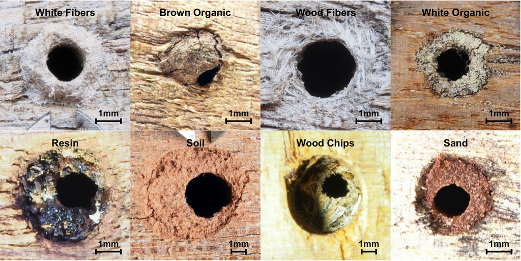

**FIGURE 1**

Photos of the eight main types of nest‐entrance construction by arboreal ants. A 1 mm scale is provided for each image

### 3.3 Nesting context and entrance modification

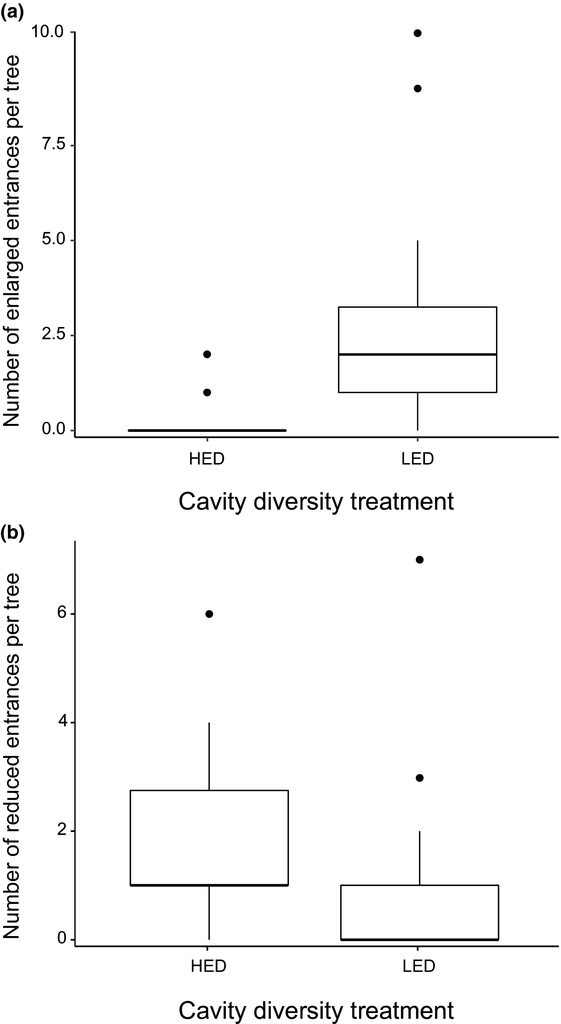

**FIGURE 2**

Boxplots of (a) enlarged and (b) reduced cavity entrances per tree in relation to the entrance‐diversity treatment: High entrance diversity (HED), with nine discrete entrance sizes and a range from 1.5 to 5.5 mm in diameter, and low entrance diversity (LED), with three discrete sizes and a range from 1.5 to 2.5 mm in diameter. Entrance‐diversity treatments mimicked extremes in the natural distribution of entrance sizes recorded in the focal system. In each boxplot, the box encompasses the interquartile range, a line is drawn at the median, whiskers extend to the upper and lower quartiles (±1.5 times the interquartile range), and filled circles identify outliers

In contrast to the context‐dependent influence of entrance diversity on modifications, tree species had no significant effect on the types and frequency of entrance reductions made by resident ant (Fisher's exact test *p* = 0.12). Notable, however, was the absence of resin‐based modifications on *Machaerium opacum*, a tree species that produces large amounts of red resin when damaged, and the absence of any white organic‐based modifications on *Tachigali aurea*. In each case, these types of modification were relatively common on other tree species.

Within the tree‐diversity experiment, we found that the likelihood of entrance modification marginally increased with size (logistic regression, *p* < 0.0001). However, the small difference between the null deviance (614.00, *df* = 652) and the residual deviance (596.43, *df* = 651) indicated that the inclusion of entrance area in the model only marginally increased the predictive power. The results were similar when running the model with only cavities occupied by ants and only cavities occupied by *Camponotus bonariensis*, which was one of the two most abundant species in the occupied cavities (below).

### 3.4 Ant diversity & entrance modifications

TABLE 2. Ant species that modified experimental nests in the entrance‐diversity experiment

| Ant species | No. modified nests (no of occupied nests) | Enlarged | Reduced | Other |
| --- | --- | --- | --- | --- |
| *Azteca* sp. 1 | 2 (31) | 2 | – | – |
| *Camponotus arboreus* (Smith, 1858) | 1(24) | 1 | – | – |
| *Camponotus bonariensis* Mayr, 1868 | 5 (54) | 3 | 2 | – |
| *Camponotus melanoticus* Emery, 1894 | 4 (18) | 1 | 3 | – |
| *Camponotus* sp. 65 | 1 (12) | – | 1 | – |
| *Camponotus senex* (Smith, 1858) | 17 (190) | 6 | 6 | 5 |
| *Cephalotes pusillus* Klug, 1824 | 60 (341) | 55 | 4 | 1 |
| *Crematogaster ampla* Forel, 1912 | 3 (25) | 1 | 2 | – |
| *Dolichoderus lutosus* (Smith, 1858) | 2 (25) | 2 | – | – |
| *Nesomyrmex* sp. 2 | 1 (4) | – | – | 1 |
| *Pseudomyrmex curacaensis* (Forel, 1912) | 17 (46) | – | 17 | – |
| *Pseudomyrmex elongatus* (Mayr, 1870) | 17 (33) | 3 | 14 | – |
| *Pseudomyrmex gracilis* (Fabricius, 1804) | 24 (127) | 9 | 15 | – |
| *Pseudomyrmex urbanus* (Smith, 1877) | 6 (36) | – | 6 | – |
| *Solenopsis* sp. 1 | 1 (5) | – | 1 | – |
| *Tapinoma* sp. 4 | 5 (9) | – | 5* | – |

### Note

- The total number of entrance modifications is further differentiated into the categories of enlargements, reductions, and other kinds of modifications. An asterisk denotes a case where one entrance was converted into two smaller entrances.

TABLE 3. Ant species that modified cavity entrances with construction materials in the tree‐diversity experiment

| Ant species | No of modified nests (no of occupied nests) | White fibers | Brown organic | Wood fibers | White organic | Resin | Soil | Sand |
| --- | --- | --- | --- | --- | --- | --- | --- | --- |
| *Camponotus bonariensis* Mayr, 1868 | 40 (143) | x | x | x | x | x |  |  |
| *Camponotus senex* (Smith, 1858) | 4 (30) | x | x | x |  |  |  |  |
| *Cephalotes borgmeieri* (Kempf, 1951) | 1 (4) |  |  |  |  |  |  |  |
| *Cephalotes pusillus* Klug, 1824 | 1 (6) |  |  |  |  |  |  |  |
| *Pseudomyrmex gracilis* (Fabricius, 1804) | 20 (56) | x | x |  | x | x | x | x |
| *Pseudomyrmex sericeus* (Mayr, 1870) | 4 (4) |  | x |  |  | x | x |  |
| *Solenopsis* sp. 1 | 1 (1) |  |  |  |  |  |  |  |

### Note

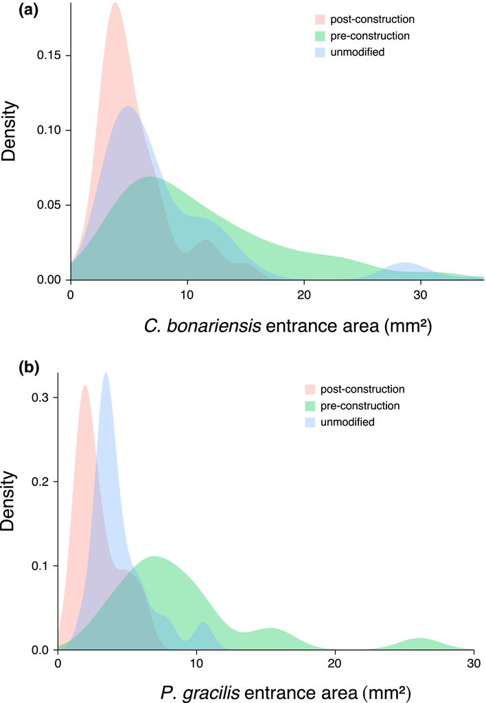

**FIGURE 3**

Kernel density plot of cavity entrance areas pre‐construction, post‐construction, and unmodified for (a) *Camponotus bonariensis* and (b) *Pseudomyrmex gracilis*. Pre‐construction and post‐construction cavities are the same cavities, the green (pre‐construction) represents the original cavity areas whereas the pink (post‐construction) represent the actual cavity entrance areas with modification. Blue (unmodified) represent cavities inhabited by the ant species that were not modified. Note: Densities for each of the three categories in these plots are weighted equally and do not represent sample sizes. Sample sizes for Figure 3a were *n* = 31 for post‐construction, *n* = 31 for pre‐construction, and *n* = 103 for unmodified. Sample sizes for Figure 3b were *n* = 20 for post‐construction, *n* = 20 for pre‐construction, and *n* = 36 for unmodified

## 4 DISCUSSION

Here, we used field experiments to examine the overarching hypothesis that entrance modifications are widespread among arboreal ants and influenced by available nest‐entrance diversity and the tree species upon which the cavities are found. Our experimental nests were occupied by 29 species, which is approximately one third of the total arboreal ant diversity within the focal community (Camacho & Vasconcelos, 2015; Camarota et al., 2016; Powell et al., 2011). Eighteen of these species engaged in some form of entrance enlargement or reduction, with entrance reductions using eight main types of construction materials seemingly derived from the host tree. Nevertheless, tree species had no significant effect on entrance modification. In contrast, the diversity of available entrances, defined as differences in number and range of entrance sizes that matched the resource extremes within the focal system, did significantly influence entrance modification. More entrance enlargement occurred when the diversity of entrances sizes was low, while more constructed entrance reductions were built when entrance diversity was high. Considered together, these findings reveal that entrance modification strategies are common, varied, and context‐dependent among arboreal cavity‐nesting ants. This phenomenon may have a number of consequences for arboreal ant communities, and suggests numerous further studies, some of which are discussed here.

Our experiments suggest that the context of the array of available entrance sizes available to the species may be especially important for understanding when entrance modification behavior might be triggered. The ants actively modified the entrances in the direction that would presumably provide a more suitable defensible nest site. Concordantly, there were differences in the direction of entrance modifications in relation to the entrance‐diversity treatments. Thus, with the lack of larger cavities available, the ants would tend to enlarge the cavity entrance sizes. And with the higher availability of large entrances, it would be more critical to reduce entrance size for a better fit. It is also noteworthy that none of the modifications resulted in entrance sizes beyond the range represented in our high diversity treatment, which was designed to match the most diverse entrance distributions recorded on trees within the focal system. Our treatments do not allow us to tease apart the relative importance of entrance size range versus the availability of specific size on modification activity. Nevertheless, by matching extremes of the natural entrance distribution, they do show that both enlargement and reduction are used to fine‐tune entrance sizes within the typical natural range that ants have available to them. The capacity of ants to choose between different nest properties, including entrance size, is well documented for ground nesting and arboreal ants (e.g., Mallon and Franks, 2000; Pratt & Pierce, 2001; Dornhaus et al., 2004; Powell, 2009). Yet the capacity for context‐dependent entrance modification based on entrance size, as documented here, in largely unstudied. Focusing on the responses of particularly abundant or active species can help further in understanding the role of entrance size in triggering entrance modifications.

Existing data suggest that improved cavity defense may be the main reason why arboreal cavity‐nesting species prefer specific entrance sizes, and thus why they modify entrances seemingly to attain a preferred size. Colonies that inhabit nests with entrances not suited to their defensive strategy may suffer higher rates of nest usurpation by competing ants (Hasegawa, 1993; Powell, 2009; Powell et al., 2017; Powell & Dornhaus, 2013). While a variety of studies suggest that an important functional relationship between ant size and entrance is widespread in arboreal ants (e.g., Powell et al., 2011; Jiménez‐Soto & Philpott, 2015; Novais et al., 2017; Camarota et al. 2020), data on how the fit between ant and entrance size facilitates defense is lacking for most taxa. Studies of this kind would therefore be a valuable focus for future work, especially in taxa that frequently modify entrances. *Pseudomyrmex* might be an especially valuable focus for such studies, as this study shows they are active nest modifiers and they are a diverse group that often appears to prefer very tight‐fitting entrances.

In addition to improved defense, entrance modification may also alleviate abiotic pressures faced by the colony. For example, restricting the area of the connection between the inside of the cavity and the outside conditions may serve to regulate humidity and temperature. Some entrance modifications have a raised, volcano‐like shape (e.g., Figure 1, white fibers) while others form a completely covered hut‐like structure that positions a newly constructed entrance horizontal to the cavity rather than perpendicular (e.g., Figure 1, brown organic). These structures may be effective ways to exclude rainwater from cavities, acting like levies around the cavity entrances, or completely shielding them from flowing water. The extent to which entrance modifications, and especially construction, buffers nests against abiotic pressures may again benefit from focal studies of species that make the most elaborate and durable entrance constructions.

Considered together, the insights gained here provide additional evidence that cavity limitation is an important constraint facing assemblages of arboreal cavity‐nesting ants. A variety of studies have used rapid colonization of supplementary cavities as an indicator of cavity limitation within a community (Jiménez‐Soto & Philpott, 2015; Mottl et al., 2020; Philpott & Foster, 2005; Philpott et al., 2018; Powell et al., 2011). Additionally, some studies have shown that a greater diversity of cavity entrances results in rapid colonization by a greater diversity of species, indicating that some members of an assemblage may be further limited by the availability of specific entrance sizes (Jiménez‐Soto & Philpott, 2015; Powell et al., 2011). Focal studies of individual species have further shown direct competition over occupied cavities, in the form of active usurpation attempts by heterospecific enemy ants, and lower survival for nests with oversized entrances (Powell, 2009; Powell et al., 2017). Here, our findings add that entrance modification is widespread among arboreal ants, and that limited availability of different entrance sizes appears to trigger entrance modification to attain a preferred size. The severity of cavity limitation undoubtedly varies between taxa, habitats, and regions. Nevertheless, our results indicate that entrance modification is a previously underappreciated but widespread strategy for utilizing available cavities that have entrance properties outside a preferred range. Further investigation into nest‐entrance modification will therefore be important for understanding how cavity limitation influences niche evolution and niche‐based community assembly in arboreal ants.

## ACKNOWLEDGEMENTS

The authors would like to thank Subject Editor Xavier Arnan and two anonymous reviewers for the valuable input to the manuscript. This work was funded by NSF grants DEB 0842144 to RJM and SP. FC and SP had additional funding from NSF grant DEB 1442256 and the George Washington University. GVP had additional funding from the Whitney R. Harris World Ecology Center. FC and HLV had additional funding from the Brazilian Council of Research and Scientific Development (CNPQ), and the Brazilian Ministry for Education (MEC/CAPES).

## AUTHOR CONTRIBUTION

For the entrance‐diversity experiment, all authors contributed to study design, implementation, data collection, and analysis. The tree‐diversity experiment was designed and completed by GVP and RJM. All authors contributed to writing the manuscript.

[Early View](https://onlinelibrary.wiley.com/toc/17447429/0/0)

Online Version of Record before inclusion in an issue

### Details

- © 2021 The Association for Tropical Biology and Conservation

### Research funding

  - Whitney R Harris World Ecology Center Grant
  - National Science Foundation Grant. Grant Numbers: DEB 0842144, DEB 1442256
  - Conselho Nacional de Desenvolvimento Científico e Tecnológico
  - Ministério da Educação, Coordenação de Aperfeicoamento de Pessoal de Nível Superior

### Publication History

  - Version of Record online: 02 March 2021
  - Manuscript accepted: 28 November 2020
  - Manuscript revised: 02 November 2020
  - Manuscript received: 25 February 2020